# Guía 15 Regresión lineal múltiple

Diplomado en Análisis de Datos y Modelamiento Predictivo con Aprendizaje Automático para la Acuicultura.

Dr. José A. Gallardo y Dra. María Angélica Rueda.

Pontificia Universidad Católica de Valparaíso  
jose.gallardo@pucv.cl

06 June 2023

### MODELOS LINEALES

Sea $Y$ una variable respuesta continua y $X_1,…,X_p$ variables predictoras, un modelo de regresión lineal múltiple se puede representar como,

$$Y_{i} = \beta_{0} + \beta_{1} X_{i1} +
\beta_{2} X_{i2} + ... + \beta_{p} X_{ip} + \epsilon_{i}$$

Supuestos:

1. No existe multicolinealidad.
2. Los residuos distribuyen **normalmente**.
3. Existe homogeneidad de varianzas.

#### **Objetivos de aprendizaje**

Los objetivos de aprendizaje de esta guía son:

**1**. - Realizar análisis de regresión lineal múltiple.

**2**. - Realizar gráficas avanzadas con ggplot2.

**3**. - Elaborar un reporte dinámico en formato html con **[Rmarkdown](https://rmarkdown.rstudio.com/)**.

## ESTUDIO DE CASO: EXPRESIÓN DE GEN ASOCIADO A MADURACIÓN EN SALMÓN

En este estudio de caso trabajaremos con un set de datos reales del estudio publicado por [Verta et al. 2020](https://doi.org/10.1371/journal.pgen.1009055). En este estudio se analiza la expresión del gen vgll3, el cual se ha asociado a la maduración en salmón del Atlántico.

La variable respuesta que analizaremos se denomina **TotCopies** y representa a las copias totales del gen expresado en la gonada de los peces. Las variables predictoras son **DPH** que representa a los días por eclosión (Days post hatching) y **VGLL3** que representa el genotipo de los peces el cual puede ser *EE* asociado a maduración temprana (Early) *LL* asociado a maduración tardía (Late).

### **Ejercicio 1.** Elaborar y configurar Reporte en formato .Rmd

Elabore un documento .Rmd y configure su reporte para exportar en html. Instale solo los paquetes que utilice para el análisis de los datos.

```r
knitr::opts_chunk$set(echo = TRUE)
library(readxl)
library(ggplot2)
library(dplyr)
library(multcomp)
library(psych)
library(car)
```

Ejecute cada uno de los siguientes ejercicios en uno o más bloques de códigos diferentes. Sea ordenado y documente su reporte adecuadamente.

### **Ejercicio 2.** Exploratorio set de datos vgll3_ancova.

Importe el set de datos **vgll3_ancova.xlsx** y realice un análisis exploratorio de datos de **TotCopies** y **DPH**.

Incluya:

**a).** Transforme variable **VLLL3** a factor y realice exploratorio de datos.

```r
vgll3_dat <- read_excel("vgll3_ancova.xlsx")
vgll3_dat$VGLL3 <- as.factor(vgll3_dat$VGLL3)
summary(vgll3_dat)
```

```
##    Individual    VGLL3   TissueOrRep          SexGeno
##  Min.   :246.0   EE:15   Length:31          Length:31
##  1st Qu.:309.0   LL:16   Class :character   Class :character
##  Median :582.0           Mode  :character   Mode  :character
##  Mean   :541.2
##  3rd Qu.:677.0
##  Max.   :974.0
##     Gonads            TotCopies         Timepoint      TissueOrGonadType
##  Length:31          Min.   : 0.4781   Min.   : 6.000   Length:31
##  Class :character   1st Qu.:23.4782   1st Qu.: 8.000   Class :character
##  Mode  :character   Median :35.6897   Median : 9.000   Mode  :character
##                     Mean   :37.5486   Mean   : 9.161
##                     3rd Qu.:49.7888   3rd Qu.:10.500
##                     Max.   :73.6309   Max.   :12.000
##       DPH
##  Min.   :164.0
##  1st Qu.:222.5
##  Median :265.0
##  Mean   :258.4
##  3rd Qu.:300.0
##  Max.   :340.0
```

**b).** Histograma de la variable respuesta **TotCopies**.

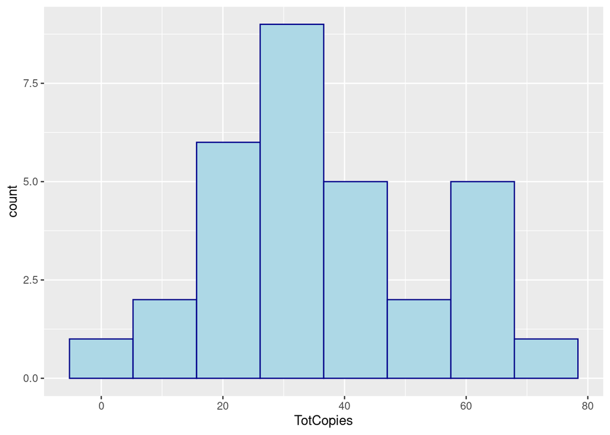

```r
ggplot(vgll3_dat, aes(x=TotCopies))+
  geom_histogram(color="darkblue", fill="lightblue", bins = 8)
```

**c).** Boxplot de la variable respuesta **TotCopies** en función del genotipo **vgll3**.

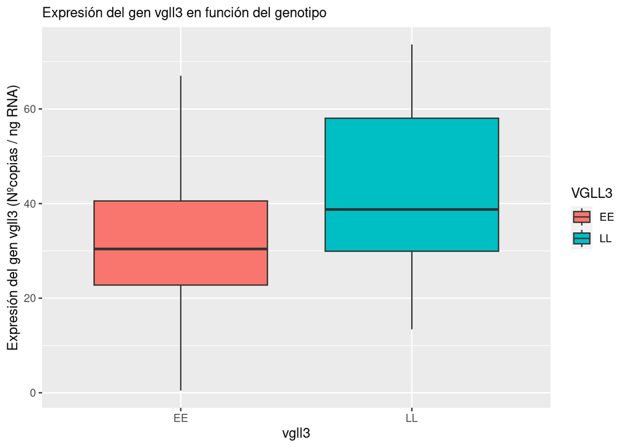

```r
vgll3_dat %>%
  ggplot(aes(x=VGLL3, y= TotCopies, fill=VGLL3)) +
  geom_boxplot() +
  labs(y="Expresión del gen vgll3 (Nºcopias / ng RNA)", x="vgll3",
       subtitle="Expresión del gen vgll3 en función del genotipo")
```

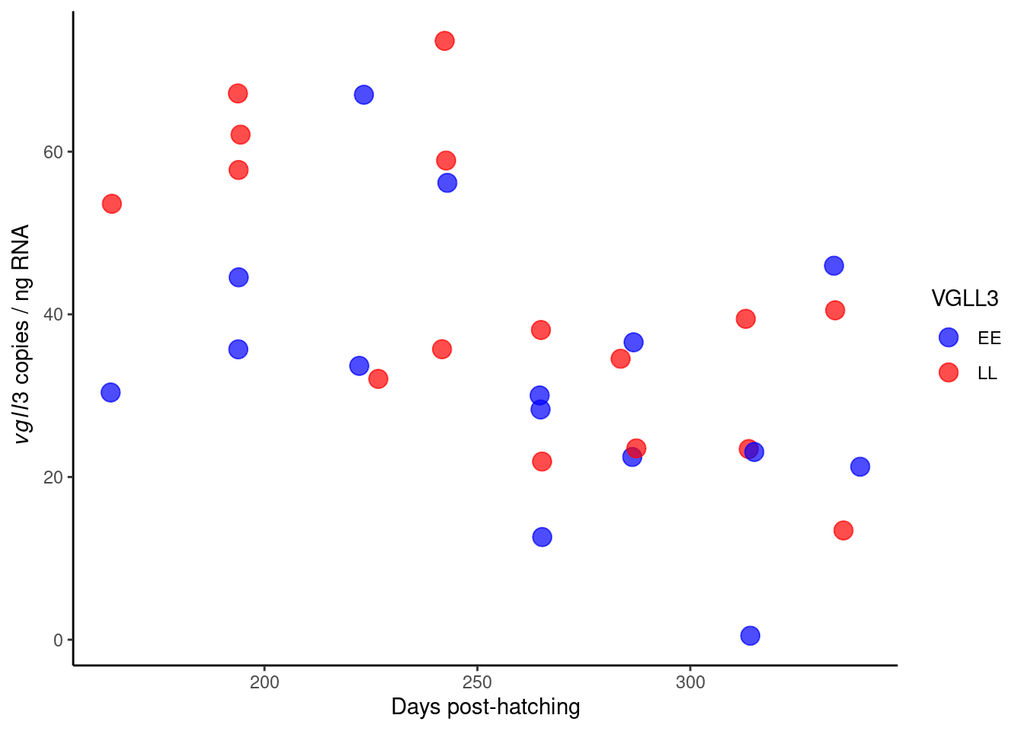

```r
vgll3_dat %>%
ggplot(aes(DPH,TotCopies,color=VGLL3,group=VGLL3)) +
  geom_jitter(size=4,alpha=0.7) +
  theme_classic() +
  scale_color_manual(values=c("blue","red")) +
  xlab("Days post-hatching") +
  ylab(expression(~italic(vgll3)~'copies / ng RNA'))
```

### **Ejercicio 3.** Análisis de covarianza.

**a).** Realice un análisis de regresión lineal para investigar la asociación entre **TotCopies** y todas las variables predictoras usando las funciones **lm()**, **summary()**.

Interprete los resultados del modelo lineal y responda las siguientes preguntas:  
- ¿Qué representan los estimadores Beta: Intercept, VGLL3LL y DPH?. - ¿Qué estimadores de Beta son significativamente distintas de cero?. - ¿Cuál es la bondad de ajuste del modelo $R^2$ ajustado? - ¿Puedo predecir la expresión del gen con este modelo lineal?

```r
fitFull <- lm(TotCopies ~ VGLL3 + DPH, vgll3_dat)
summary(fitFull)
```

```
##
## Call:
## lm(formula = TotCopies ~ VGLL3 + DPH, data = vgll3_dat)
##
## Residuals:
##     Min      1Q  Median      3Q     Max
## -22.592  -8.883  -2.586   8.742  28.880
##
## Coefficients:
##             Estimate Std. Error t value Pr(>|t|)
## (Intercept) 78.96643   13.89391   5.684  4.3e-06 ***
## VGLL3LL      8.86410    5.30109   1.672  0.10564
## DPH         -0.17801    0.05125  -3.474  0.00169 **
## ---
## Signif. codes:  0 '***' 0.001 '**' 0.01 '*' 0.05 '.' 0.1 ' ' 1
##
## Residual standard error: 14.74 on 28 degrees of freedom
## Multiple R-squared:  0.355,  Adjusted R-squared:  0.3089
## F-statistic: 7.705 on 2 and 28 DF,  p-value: 0.002157
```

**b).** Realice una gráfica de regresión lineal para representar la asociación de cada genotipo con la variable respuesta. Para ello investigue y use el comando **geom_smooth()**.

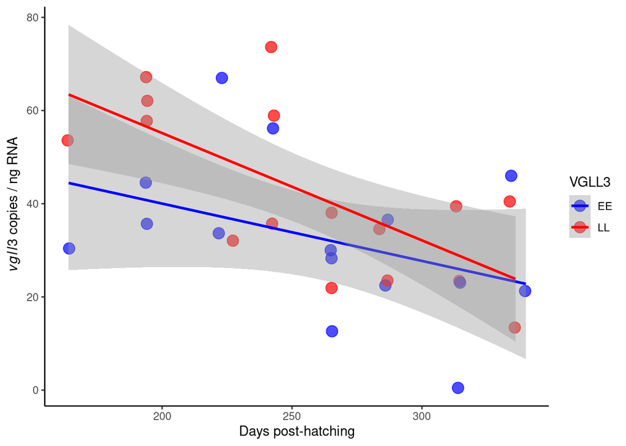

```r
vgll3_dat %>%
ggplot(aes(DPH,TotCopies,color=VGLL3,group=VGLL3)) +
  geom_jitter(size=4,alpha=0.7) +
  theme_classic() +
   geom_smooth(method="lm", formula=y~x, se=T) +
  scale_color_manual(values=c("blue","red")) +
  xlab("Days post-hatching") +
  ylab(expression(~italic(vgll3)~'copies / ng RNA'))
```

**c).** Realice un análisis de covarianza e interprete los resultados, use la función **anova()** sobre el modelo lineal realizado en el ejercicio 3a.

```r
anova(fitFull)
```

```
## Analysis of Variance Table
##
## Response: TotCopies
##           Df Sum Sq Mean Sq F value   Pr(>F)
## VGLL3      1  726.2  726.20  3.3446 0.078098 .
## DPH        1 2619.8 2619.78 12.0656 0.001689 **
## Residuals 28 6079.6  217.13
## ---
## Signif. codes:  0 '***' 0.001 '**' 0.01 '*' 0.05 '.' 0.1 ' ' 1
```

### **Ejercicio 4.** Evaluación de supuestos modelo completo.

**a).** Evalue los supuestos de multicolinealidad, normalidad y homogeneidad de varianzas.

```r
# Multicolinealidad por vif
vif(fitFull)
```

```
##    VGLL3      DPH
## 1.001992 1.001992
```

```r
# Normalidad
shapiro.test (residuals (fitFull))
```

```
##
##  Shapiro-Wilk normality test
##
## data:  residuals(fitFull)
## W = 0.95801, p-value = 0.2581
```

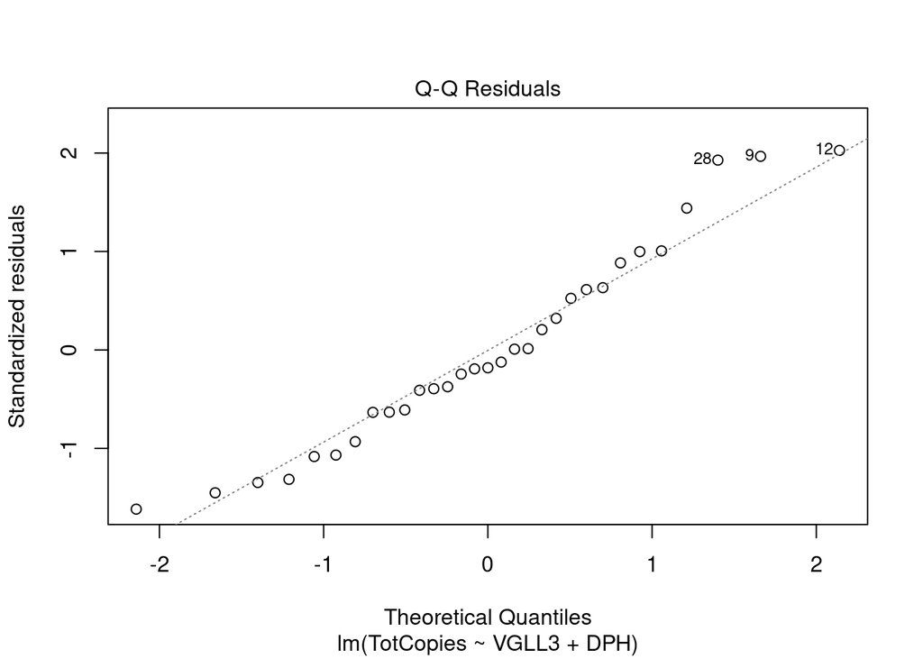

```r
plot(fitFull, which = 2)
```

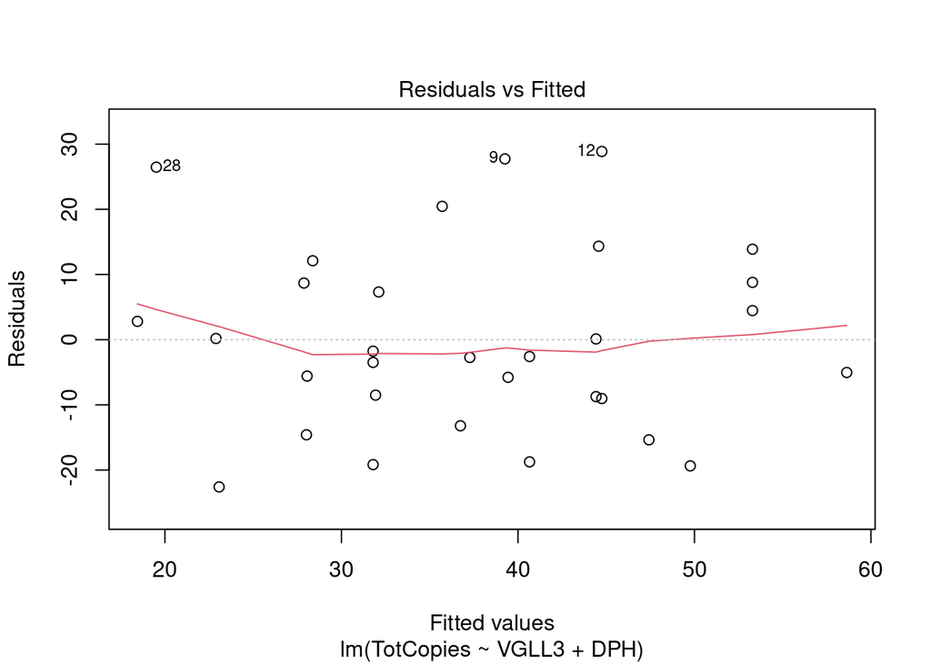

```r
# Homogeneidad de varianzas usando plot
plot(fitFull, which = 1)
```

### **Ejercicio 5.** Comparación modelo completo y modelo reducido

Dado que uno de los factores (Genotipo) no afecta a la variable respuesta. Elabore un modelo reducido y compare usando usando los residuales y el criterio AIC.

**a).** Elabore un modelo reducido solo con la variable **DPH**.

```r
fitSimple <- lm(TotCopies ~ DPH, vgll3_dat)
summary(fitSimple)
```

```
##
## Call:
## lm(formula = TotCopies ~ DPH, data = vgll3_dat)
##
## Residuals:
##     Min      1Q  Median      3Q     Max
## -26.954 -10.033  -4.006  12.330  33.106
##
## Coefficients:
##             Estimate Std. Error t value Pr(>|t|)
## (Intercept) 84.52858   13.90129   6.081 1.28e-06 ***
## DPH         -0.18183    0.05276  -3.447  0.00175 **
## ---
## Signif. codes:  0 '***' 0.001 '**' 0.01 '*' 0.05 '.' 0.1 ' ' 1
##
## Residual standard error: 15.18 on 29 degrees of freedom
## Multiple R-squared:  0.2906, Adjusted R-squared:  0.2661
## F-statistic: 11.88 on 1 and 29 DF,  p-value: 0.001754
```

**b).** Compare los modelos completo usando residuales. Ej. anova(fulmodel, simplemodel)

¿Hay diferencias significativas entre los modelos?

```r
# Comparación usando residuales
res <- anova(fitFull, fitSimple)
pander::pander(res, caption = "Comparación modelos usando residuales.")
```

Comparación modelos usando residuales.

| Res.Df | RSS | Df | Sum of Sq | F | Pr(>F) |
| --- | --- | --- | --- | --- | --- |
| 28 | 6080 | NA | NA | NA | NA |
| 29 | 6687 | -1 | -607.1 | 2.796 | 0.1056 |

**c).** Compare los modelos completo usando el crirterio AIC. Ej. AIC(fulmodel, simplemodel)

¿Cuál es el mejor modelo según el criterio AIC?

```r
# Comparación usando AIC
aic <- AIC(fitFull, fitSimple)

pander::pander(aic, caption = "Comparación modelos usando AIC.")
```

Comparación modelos usando AIC.

|  | df | AIC |
| --- | --- | --- |
| **fitFull** | 4 | 259.6 |
| **fitSimple** | 3 | 260.6 |